# FordGoBike - Tripdata

# DataSet Overview

### This Dataset is from FordGoBike - tripdata where the data has around 16 Variables explaining the users behaviour in using the company service.

> duration_sec  
> start_time  
> end_time  
> start_station_id  
> start_station_name  
> start_station_latitude  
> start_station_longitude  
> end_station_id  
> end_station_name  
> end_station_latitude  
> end_station_longitude  
> bike_id  
> user_type  
> Date_time_start  
> Date_time_end  
> dtype: object

### This data has the informations not for the Whole year but we have the data for the Second part of the year (i.e) from the June 2017 to December 2017

```python
df.describe()
```

|  | duration_sec | start_station_id | start_station_latitude | start_station_longitude | end_station_id | end_station_latitude | end_station_longitude | bike_id |
| --- | --- | --- | --- | --- | --- | --- | --- | --- |
| count | 519700.000000 | 519700.000000 | 519700.000000 | 519700.000000 | 519700.000000 | 519700.000000 | 519700.000000 | 519700.000000 |
| mean | 1099.009521 | 95.034245 | 37.771653 | -122.363927 | 92.184041 | 37.771844 | -122.363236 | 1672.533079 |
| std | 3444.146451 | 86.083078 | 0.086305 | 0.105573 | 84.969491 | 0.086224 | 0.105122 | 971.356959 |
| min | 61.000000 | 3.000000 | 37.317298 | -122.444293 | 3.000000 | 37.317298 | -122.444293 | 10.000000 |
| 25% | 382.000000 | 24.000000 | 37.773492 | -122.411726 | 23.000000 | 37.774520 | -122.410345 | 787.000000 |
| 50% | 596.000000 | 67.000000 | 37.783521 | -122.398870 | 66.000000 | 37.783830 | -122.398525 | 1728.500000 |
| 75% | 938.000000 | 139.000000 | 37.795392 | -122.391034 | 134.000000 | 37.795392 | -122.391034 | 2520.000000 |
| max | 86369.000000 | 340.000000 | 37.880222 | -121.874119 | 340.000000 | 37.880222 | -121.874119 | 3733.000000 |

```python
# Check for Duplicates in the dataset
df.duplicated().sum()
```

```
0
```

```python
# We will extract the time from the timestamp
df['start_time_hour']= df['start_time'].dt.hour
```

```python
df.head()
```

|  | duration_sec | start_time | end_time | start_station_id | start_station_name | start_station_latitude | start_station_longitude | end_station_id | end_station_name | end_station_latitude | end_station_longitude | bike_id | user_type | hire_day | hire_end_day | month | start_time_hour |
| --- | --- | --- | --- | --- | --- | --- | --- | --- | --- | --- | --- | --- | --- | --- | --- | --- | --- |
| 0 | 80110 | 2017-12-31 16:57:39.654 | 2018-01-01 15:12:50.245 | 74 | Laguna St at Hayes St | 37.776435 | -122.426244 | 43 | San Francisco Public Library (Grove St at Hyde... | 37.778768 | -122.415929 | 96 | Customer | Sunday | Monday | December | 16 |
| 1 | 78800 | 2017-12-31 15:56:34.842 | 2018-01-01 13:49:55.617 | 284 | Yerba Buena Center for the Arts (Howard St at ... | 37.784872 | -122.400876 | 96 | Dolores St at 15th St | 37.766210 | -122.426614 | 88 | Customer | Sunday | Monday | December | 15 |
| 2 | 45768 | 2017-12-31 22:45:48.411 | 2018-01-01 11:28:36.883 | 245 | Downtown Berkeley BART | 37.870348 | -122.267764 | 245 | Downtown Berkeley BART | 37.870348 | -122.267764 | 1094 | Customer | Sunday | Monday | December | 22 |
| 3 | 62172 | 2017-12-31 17:31:10.636 | 2018-01-01 10:47:23.531 | 60 | 8th St at Ringold St | 37.774520 | -122.409449 | 5 | Powell St BART Station (Market St at 5th St) | 37.783899 | -122.408445 | 2831 | Customer | Sunday | Monday | December | 17 |
| 4 | 43603 | 2017-12-31 14:23:14.001 | 2018-01-01 02:29:57.571 | 239 | Bancroft Way at Telegraph Ave | 37.868813 | -122.258764 | 247 | Fulton St at Bancroft Way | 37.867789 | -122.265896 | 3167 | Subscriber | Sunday | Monday | December | 14 |

# Analysing the data

#### What is the structure of your dataset?

> trip duration: how long the trip took in seconds

> start time/end time: start/end date/time for the bike rides.

> stations: start/end station, name, geolocation (latitude/longitude)

> rented bikes: bike id

Further exploration to enhance the features that I may find neccessary to perform interesting analysis rental time: hour of the day, weekday

> **What is/are the main feature(s) of interest in your dataset?**

> **My area of interest is to invetigate the actual duration of biking time.**

> **What features in the dataset do you think will help support your investigation into your feature(s) of interest?**

> To me the following features may help to support my investigation into the feature (duration) I am interested in.

> **user_type**

> **start_time - I'll extract dayofweek, hours for further investigation.**

> **month - I'll extract month, hours for further investigation.**

> **time_of_day - I'll extract month, hours for further investigation.**

# FordGOBike - Exploratory visualizations -UNIVARIATE EXPLORATION

> - **In this section, I will be performing univariate explaration of the variables of interest and others in the dataset.**

# Question

##### We will now find the duration of Average time of the service used by the Users in the dataset.?

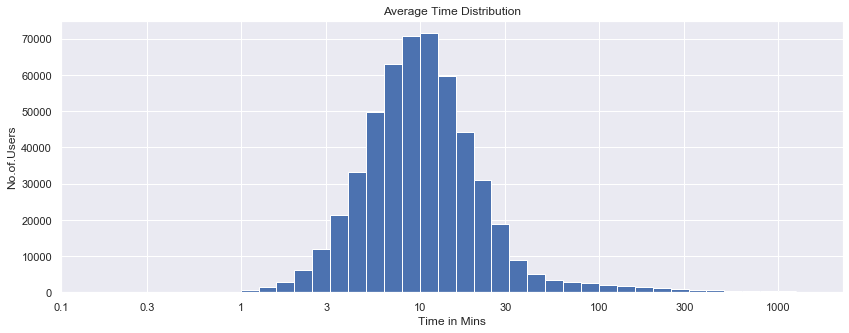

```python
# We will now apply bins to the log scale and explictly apply the ticks to the x axis
bins_x = 10 ** np.arange(0,3.2+0.1,0.1)
ticks = [0.1,0.3,1,3,10,30,100,300,1000]
labels = ['{}'.format(v) for v in ticks]
plt.figure(figsize = [14, 5])
plt.hist(data = new_df, x = 'time_mins',bins = bins_x)
plt.xscale('log')
plt.xticks(ticks,labels)
plt.xlabel('Time in Mins')
plt.ylabel('No.of.Users')
plt.title('Average Time Distribution');
```

# Observation

> **After applying the log scale we can have a clear view of the data.**

> **So we can now say definetly that both the customers and the subscribers use the service for average time is between 3 - 30 mins from the above histogram.**

# Question

##### We will now check about the user types the company has the most.?

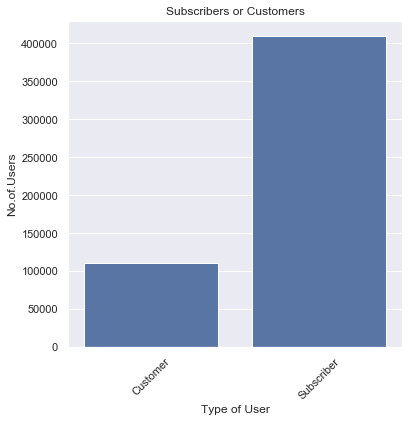

```python
# We will now plot a bar chart
base_color = sb.color_palette()[0]
plt.figure(figsize=(6,6))
sb.countplot(data = new_df, x = 'user_type', color = base_color)
plt.xticks(rotation = 45)
plt.xlabel('Type of User')
plt.ylabel('No.of.Users')
plt.title('Subscribers or Customers');
```

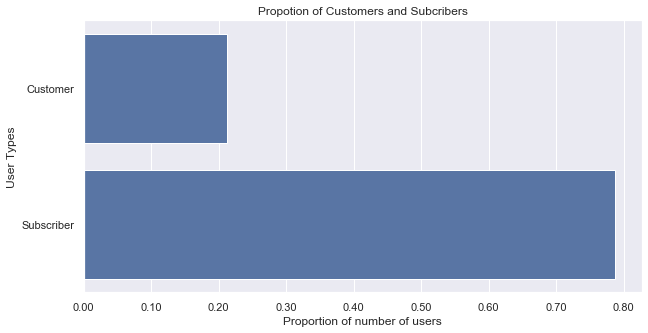

```python
# generate tick mark locations and names
tick_props = np.arange(0, max_prop+0.1, 0.1)
tick_names = ['{:0.2f}'.format(v) for v in tick_props]

# create the plot
base_color = sb.color_palette()[0]
plt.figure(figsize=(10,5))
sb.countplot(data = new_df, y = 'user_type', color = base_color)
plt.xticks(tick_props * n_points, tick_names)
plt.xlabel('Proportion of number of users')
plt.ylabel('User Types')
plt.title('Propotion of Customers and Subcribers');
```

# Observations

> - **From the above the chart we can come to know that the company has more than 78% Subscribers and around 22% customers.**

# Question

##### We will now look the difference in the Average time of the service utilised by the users seperately (i.e) average time of the subscribers and average time of the customers.?

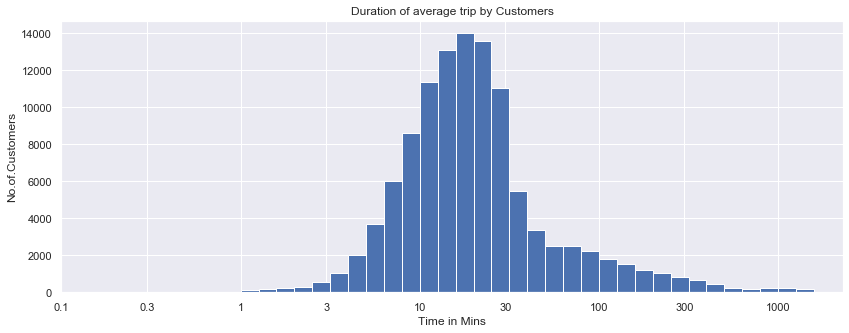

```python
# We will now apply bins to the log scale and explictly apply the ticks to the x axis

# we will now plot only customer dataset
bins_x = 10 ** np.arange(0,3.2+0.1,0.1)
ticks = [0.1,0.3,1,3,10,30,100,300,1000]
labels = ['{}'.format(v) for v in ticks]
plt.figure(figsize = [14, 5])
plt.hist(data = customer, x = 'time_mins',bins = bins_x)
plt.xscale('log')
plt.xticks(ticks,labels)
plt.xlabel('Time in Mins')
plt.ylabel('No.of.Customers')
plt.title('Duration of average trip by Customers');
```

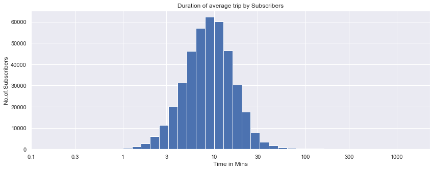

```python
# We will now apply bins to the log scale and explictly apply the ticks to the x axis

# we will now plot only subscribers dataset
bins_x = 10 ** np.arange(0,3.2+0.1,0.1)
ticks = [0.1,0.3,1,3,10,30,100,300,1000]
labels = ['{}'.format(v) for v in ticks]
plt.figure(figsize = [14, 5])
plt.hist(data = subscriber, x = 'time_mins',bins = bins_x)
plt.xscale('log')
plt.xticks(ticks,labels)
plt.xlabel('Time in Mins')
plt.ylabel('No.of.Subscribers')
plt.title('Duration of average trip by Subscribers');
```

# Insights

> - **From the above two graphs we have a surprising details that although the company has only 22% customers they are the users who tend to use the service of the company for longer time when compared to the subscribers. There are less subscribers who tend to use the service for longer time is less.**
> - **to be precise we can say that the Average time of the subsribers Fall in the range between (1 -50 mins) while the customers tend to use the service for longer time (i.e) the average time fall between ( 1- 350 mins).**

# Question

##### We will now examine the preferred day for the user to hire the service.?

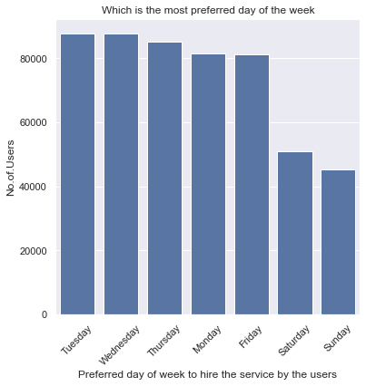

```python
# we will now plot the bar chart to find the prefrred day for the user to hire

orders  = new_df['hire_day'].value_counts().index

base_color = sb.color_palette()[0]
plt.figure(figsize=(6,6))
sb.countplot(data = new_df, x = 'hire_day', color = base_color,order = orders)
plt.xticks(rotation = 45)
plt.xlabel('Preferred day of week to hire the service by the users')
plt.ylabel('No.of.Users')
plt.title('Which is the most preferred day of the week');
```

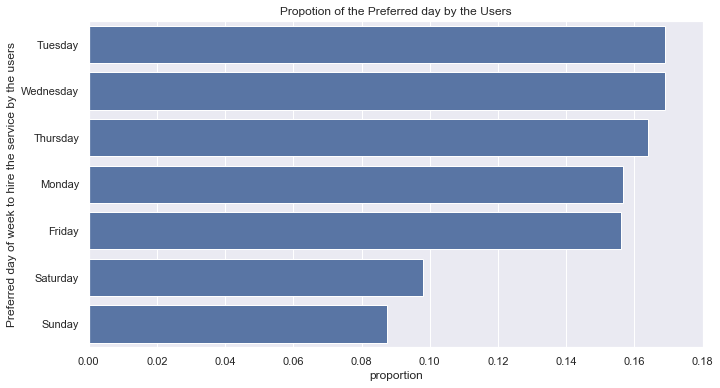

```python
# generate tick mark locations and names
tick_props_1 = np.arange(0, max_prop_1+0.02, 0.02)
tick_names_1 = ['{:0.2f}'.format(v) for v in tick_props_1]

# create the plot
base_color = sb.color_palette()[0]
plt.figure(figsize=(11,6))
sb.countplot(data = new_df, y = 'hire_day', color = base_color,order = orders)
plt.xticks(tick_props_1 * n_points_1, tick_names_1)
plt.xlabel('proportion')
plt.ylabel('Preferred day of week to hire the service by the users')
plt.title('Propotion of the Preferred day by the Users');
```